# Recent Advances in Interactive Graphics for Data Analysis

August 22nd, 2015

## … *on the Web*

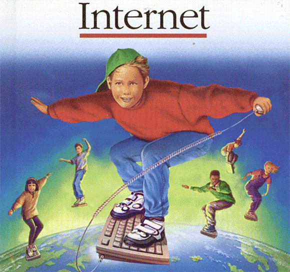

## Why interactive graphics *on the Web*?

1. Portable (web browser)
2. Simple (share via URL)
3. Reach (everyone has internet, right?)

## Figure converters

```r
library(gridSVG)
gridsvg("iris.svg")
  qplot(data = iris, x = Sepal.Width, y = Sepal.Length, color = Species)
dev.off()
```

[figure not shown]

## What is gridSVG?

- What is **grid**?
  - A low-level graphics system for R.
  - Popular graphics packages such as **lattice** and **ggplot2** are built on top of grid.
- What is Scalable Vector Graphics (SVG)?
  - A markup language, designed for the Web, providing graphical primitives.
- **gridSVG** translates **grid** graphics to SVG.
- Several R packages use **gridSVG** to *serialize* a grid graphic, and add JavaScript to enable interactivity.
  - Pros: Don't have to write a serializer/compiler.
  - Cons: What if **gridSVG** changes (moving target dilemma)?

```r
library(animint)
p <- qplot(data = iris, x = Sepal.Width, y = Sepal.Length, color = Species)
structure(list(p = p), class = "animint")
```

[interactive chart not shown]

## Extending ggplot2 to Enable Linked Interactions

## Motivating Example

[interactive chart not shown]

## The Code

```r
tips$sex_smoker <- with(reshape2::tips, interaction(sex, smoker))
library(animint)
p1 <- ggplot() + theme(legend.position = "none") +
  geom_point(data = tips, position = "jitter",
             aes(x = sex, y = smoker, colour = sex_smoker,
                 clickSelects = sex_smoker))
p2 <- ggplot() +
  geom_point(data = tips,
             aes(x = total_bill, y = tip, colour = sex_smoker,
                 showSelected = sex_smoker))
plots <- list(
  plot1 = p1,
  plot2 = p2,
  selector.types = list(sex_smoker = "multiple")
)
structure(plots, class = "animint")
```

- `animint2dir()` translates a list of ggplots to a JSON object.
- Add specially named elements to the plot list to customize rendering.

## `ggplot2`'s grammar of graphics

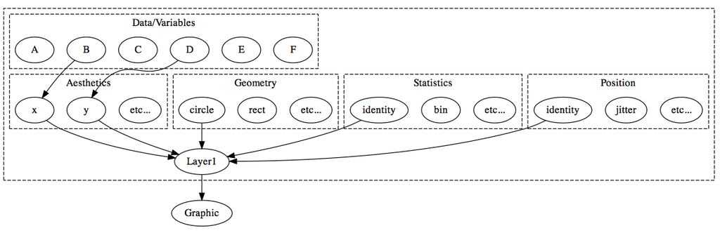

- There are 5 components to a layer: Data, Aesthetics, Statistics, Geometry, and Positional Adjustment.
- Elegantly specify static visualizations that may not fit a "plot type" (this one happens to be a scatterplot).
- In **ggplot2**, a graphic consists of one *or more* layers

## `animint`'s extension

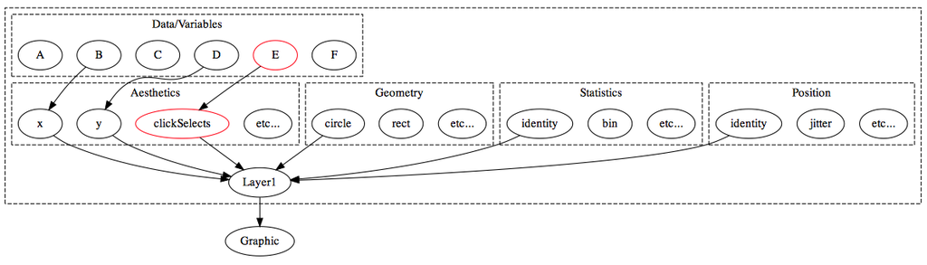

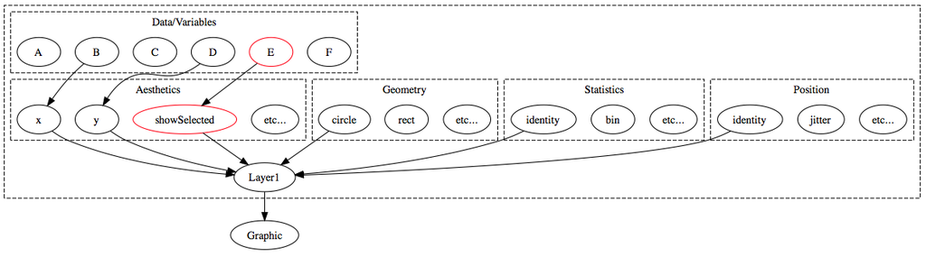

## What does this buy us?

- In general, `clickSelects`/`showSelected` specifies a link between m and n observations.
- Statistically speaking, this yields sets of visualizations of *conditional* distributions – where the conditioning variable is *categorical*.
- If you want to condition on a *quantitative* variable, you can discretize beforehand.
- This kind of linked selection can be extended to other techniques (for example, `hoverSelects`).
- A number of other interative features have fit nicely into this framework:
  - `tooltip` aesthetic for labelling.
  - `time` "aesthetic" for automatic iteration and interpolation between views (in other words, animation).

## Climate data

```r
data(climate, package = "animint")
library("dplyr")
climate %>% select(id, lat, long, date, temperature)
```

[interactive chart not shown]

```r
library("lubridate")
library("maps")

# restrict to central/south america
countries <- map_data("world") %>%
  filter(lat < 38, lat > -24) %>%
  filter(long < -54, long > -118)

# compute temperature deviation from monthly norm
climate <- climate %>%
  group_by(id, month) %>%
  summarise(avgtemp = mean(temperature)) %>%
  left_join(climate) %>%
  mutate(tempdev = temperature - avgtemp) %>%
  mutate(time_num = decimal_date(ymd(date))) %>%
  arrange(desc(time_num)) %>% as.data.frame()

dates <- climate %>%
  select(date, year, time_num) %>% unique() %>%
  mutate(textdate = paste(month(date, label = TRUE), year))
```

```r
ts <- ggplot() +
  geom_line(data = climate,
            aes(x = time_num, y = temperature, group = id, showSelected = id)) +
  geom_text(data = dates,
            aes(x = 1998, y = -5, label = textdate, showSelected = time_num)) +
  make_tallrect(data = climate, "time_num")

tile_map <- ggplot() +
  geom_tile(data = climate,
            aes(x = long, y = lat, fill = tempdev, clickSelects = id, showSelected = time_num)) +
  geom_path(data = countries, aes(x = long, y = lat, group = group)) +
  geom_text(data = dates,
            aes(x = -86, y = 39, label = textdate, showSelected = time_num)) +
  scale_fill_gradient2("deg. C") +
  ggtitle("Temperature Deviation from Monthly Norm") +
  theme(axis.line = element_blank(), axis.text = element_blank(),
      axis.ticks = element_blank(), axis.title = element_blank())

p_list <- list(ts = ts, map = tile_map, selector.types = list(id = "multiple"),
               time = list(variable = "time_num", ms = 3000))
animint2dir(p_list)
```

[interactive chart not shown]

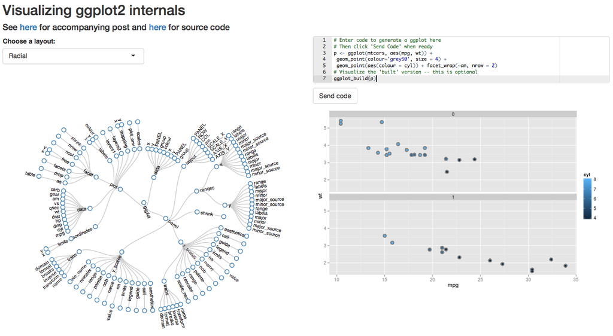

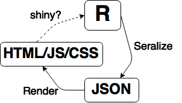

```r
library(plotly)
ggplotly(p)
```

```html
<html>
  <head>
    <script type="text/javascript" src="animint.js"></script>
  </head>
  <body>
    <div id="plot" align="center"> </div>
    <script>
      var plot = new animint("#plot","plot.json");
    </script>
  </body>
</html>
```

## How do we test the renderer?

- [RSelenium](http://cran.r-project.org/web/packages/RSelenium/index.html) allows you to program any modern Web browser from R.

```r
library(RSelenium)
startServer()
remDr <- remoteDriver(browserName = "firefox")
remDr$open()
remDr$navigate("http://www.r-project.org")
# returns the DOM as HTML
src <- remDr$getPageSource()
```

- Can also do fancier stuff like handle user events (mouse clicks, press keys, etc.)
- If you just need to access the DOM, rdom is easier and more reliable.

```r
src <- rdom::rdom("http://www.r-project.org")
```

## Thoughts on figure converters

- Pros:
  - Users don't need HTML/JS/CSS knowledge
  - Doesn't require a Web Server running special software
  - Easy to use – extrapolates on existing knowledge/code
- Cons:
  - Serialization depends on internals of other packages
  - To change something that's serialized, you need to re-run R code
  - Hard to extend, customize, and/or add (interactive) features

## R Bindings to JavaScript Libraries

- General idea:
  - Start with a HTML/JS/CSS template
  - Abstract away data and layout/appearance options
  - Map a set of R objects to template

```r
myWrapper <- function(...) {
  # compute stuff
  toJSON(list(...))
}
```

- [htmlwidgets](http://www.htmlwidgets.org/) makes it easy to write bindings that play nicely with shiny/rmarkdown/RStudio.

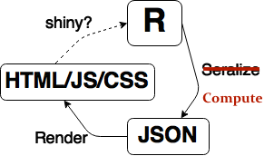

```r
(p <- plot_ly(z = volcano, type = "surface"))
```

[interactive chart not shown]

```r
str(p)
```

```
#> Classes ‘plotly’ and 'data.frame':   0 obs. of  0 variables
#>  - attr(*, "plotly_hash")= chr "d72417c2f38125f11112cd6591f06f2e#2"
```

```r
str(plotly_build(p))
```

```
#> List of 4
#>  $ data          :List of 1
#>   ..$ :List of 3
#>   .. ..$ type      : chr "surface"
#>   .. ..$ z         : num [1:87, 1:61] 100 101 102 103 104 105 105 106 107 108 ...
#>   .. ..$ colorscale:'data.frame':    10 obs. of  2 variables:
#>   .. .. ..$ : num [1:10] 0 0.111 0.222 0.333 0.444 ...
#>   .. .. ..$ : Factor w/ 10 levels "#1F9D89","#26838E",..: 6 7 5 3 2 1 4 8 9 10
#>  $ layout        :List of 1
#>   ..$ zaxis:List of 1
#>   .. ..$ title: chr "volcano"
```

```r
plot_ly(economics, x = date, y = uempmed, mode = "markers") %>%
  add_trace(y = fitted(forecast::Arima(uempmed, c(1,0,0))), mode = "lines") %>%
  dplyr::filter(uempmed == max(uempmed)) %>%
  layout(annotations = list(x = date, y = uempmed, text = "Peak", showarrow = T),
         title = "Median duration of unemployment (in weeks)", showlegend = F)
```

[interactive chart not shown]

## Thoughts on JavaScript bindings

- Defaults/abstractions matter!
  - Best when used to attack a specific problem/task
- Pros:
  - Users don't need HTML/JS/CSS knowledge
  - Package authors can easily bring the best of JavaScript to R
- Cons:
  - JavaScript developers don't think like statisticians
  - How do you abstract away reactivity/interactivity???

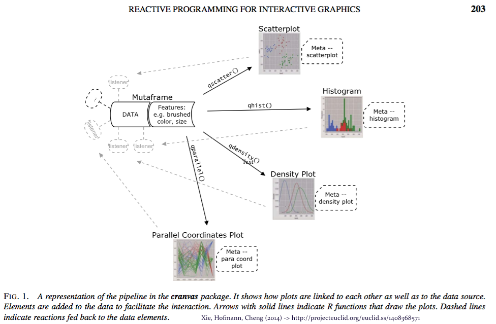

## Final Thoughts

- Web-based interactive statistical graphics are not (yet) as fully featured as non Web-based options (see loon, cranvas, mondrian, ggobi, MANET, LISP-STAT, DataDesk, etc.)
- Plea to developers:
  - build tools for domain specific problems (see qtlcharts, LDAvis)
  - focus less on features, more on what your audience really needs

## My Awesome Collaborators

- **animint**
- Toby Dylan Hocking, Susan VanderPlas, Kevin Ferris, and Tony Tsai
- **plotly**
- Toby Dylan Hocking, Chris Parmer, [Plotly Team](https://plot.ly/company/team/), and [ropensci](https://ropensci.org/)

## Thanks for listening!

- Slides -> http://bit.ly/jsm15graphics/
- Twitter -> https://twitter.com/cpsievert
- GitHub -> https://github.com/cpsievert